# Assignment_1

Author

Yuying Cheng

````markdown
```{r setup}
#| message: false
#| warning: false

library(ggplot2)
library(knitr)
library(kableExtra)
library(dplyr)
library(tidyverse)
library(stringr)
library(RColorBrewer)

fixed_palette <- "Dark2"
set_style <- function(p){
  return(p +
           theme_classic() +
           theme(legend.position = "top") +
           scale_color_brewer(palette = fixed_palette)+
           scale_fill_brewer(palette = fixed_palette))
}
```
````

# Task 4 - R basic operations

```r
sqrt(10)
```

```
[1] 3.162278
```

```r
log2(32)
```

```
[1] 5
```

```r
sum <- 0
for (i in seq(1, 1000)){
  sum <- sum + i
}
sum
```

```
[1] 500500
```

```r
sum <- 0
for (i in seq(2, 1000, 2)){
  sum <- sum + i
}
sum
```

```
[1] 250500
```

```r
choose(100, 2)
```

```
[1] 4950
```

```r
choose(100, 3)
```

```
[1] 161700
```

# Task 5 - Using R example datasets

## What is the average and median CO2 uptake of the plants from Quebec and Mississippi?

```r
data(CO2)
head(CO2) %>%
  kbl() %>%
  kable_styling()
CO2 %>%
  group_by(Type) %>%
  summarise(median = median(uptake), average = mean(uptake)) %>%
  kbl() %>%
  kable_styling()
```

| Plant | Type | Treatment | conc | uptake |
| --- | --- | --- | --- | --- |
| Qn1 | Quebec | nonchilled | 95 | 16.0 |
| Qn1 | Quebec | nonchilled | 175 | 30.4 |
| Qn1 | Quebec | nonchilled | 250 | 34.8 |
| Qn1 | Quebec | nonchilled | 350 | 37.2 |
| Qn1 | Quebec | nonchilled | 500 | 35.3 |
| Qn1 | Quebec | nonchilled | 675 | 39.2 |

| Type | median | average |
| --- | --- | --- |
| Quebec | 37.15 | 33.54286 |
| Mississippi | 19.30 | 20.88333 |

## In the “airway” example data from Bioconductor, how many genes are expressed in each sample? How many genes are not expressed in any sample?

| sample | count | category |
| --- | --- | --- |
| SRR1039508 | 24633 | expressed |
| SRR1039509 | 24527 | expressed |
| SRR1039512 | 25699 | expressed |
| SRR1039513 | 23124 | expressed |
| SRR1039516 | 25508 | expressed |
| SRR1039517 | 25998 | expressed |
| SRR1039520 | 24662 | expressed |
| SRR1039521 | 23991 | expressed |
| SRR1039508 | 39469 | not_expressed |
| SRR1039509 | 39575 | not_expressed |
| SRR1039512 | 38403 | not_expressed |
| SRR1039513 | 40978 | not_expressed |
| SRR1039516 | 38594 | not_expressed |
| SRR1039517 | 38104 | not_expressed |
| SRR1039520 | 39440 | not_expressed |
| SRR1039521 | 40111 | not_expressed |

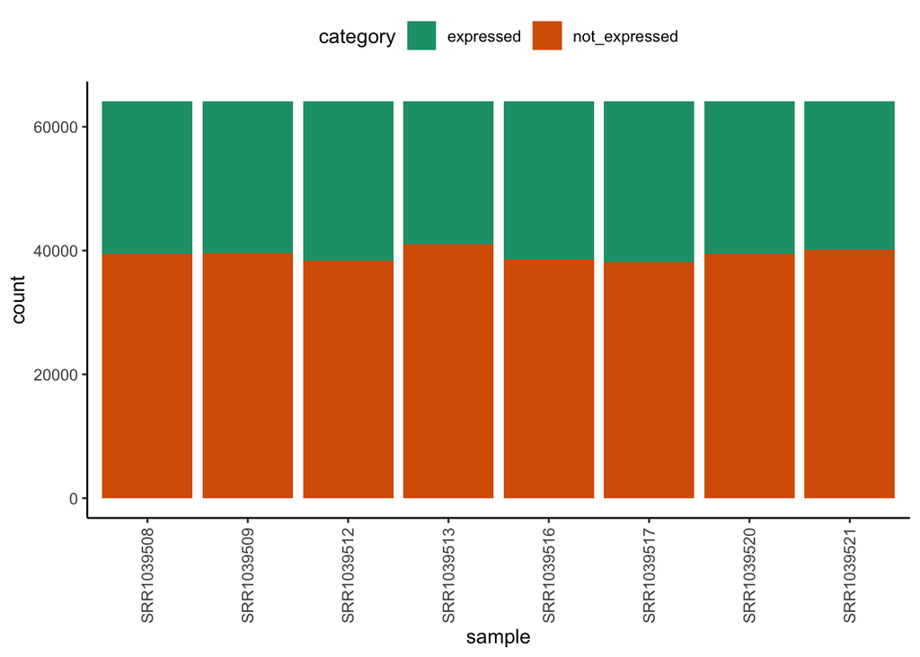

```r
library(airway)
data(airway)
expressed_no <- list(
  expressed = ~sum(.x > 0),
  not_expressed = ~sum(.x == 0)
)
df <- as.data.frame(assay(airway)) %>%
  summarise_all(.fun = expressed_no,
                .names = "{.col}.{.fn}") %>%
  gather(sample, count) %>%
  mutate(category = str_extract(sample, "expressed|not_expressed"),
         sample = str_remove(sample, ".expressed|.not_expressed"))
df %>%
  kbl() %>%
  kable_styling()
p <- ggplot(df, aes(x = sample, y = count, fill = category)) +
  geom_bar(stat = "identity")
set_style(p) +
  theme(axis.text.x = element_text(angle = 90, vjust = 0.5, hjust=1))
```

# Task 6 - R Functions

## Write a function that calculates the ratio of the mean and the median of a given vector.

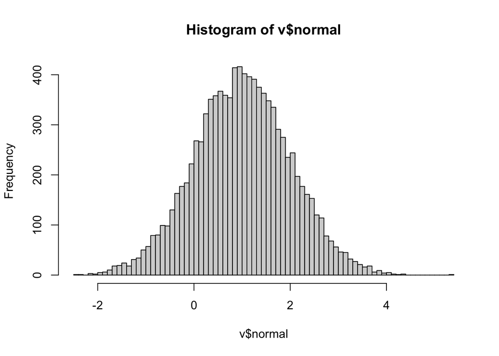

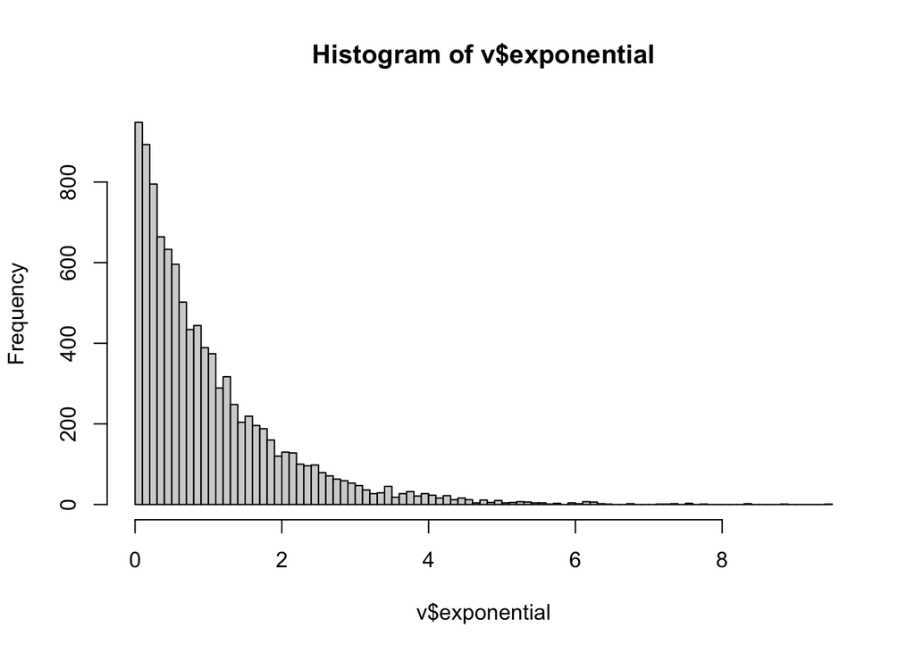

```
$normal
[1] 1.003648

$exponential
[1] 1.456794
```

```r
#Calculates the ratio of mean and median of a given vector
#input: a numeric vector
#output: the ratio of mean and median of the vector
r_mean_median <- function(v){
  return(mean(v)/median(v))
}

#test
v <- list(normal = rnorm(10000, mean = 1),
          exponential = rexp(10000, rate = 1))
hist(v$normal, breaks = 100)
hist(v$exponential, breaks = 100)
lapply(v, r_mean_median)
```

## Write a function that ignores the lowest and the highest value from a given vector and calculate the mean.

```r
#Calculates mean of a vectore after removing *one* maximum and *one* minimum
#input: a vector
#output: mean value after removal of one maximum and one minimum
adjusted_average <- function(v){
  x = sum(v) - min(v) - max(v)
  return(x/(length(v)-2))
}

#test
v = c(seq(1,3), rep(10,3))
v
```

```
[1]  1  2  3 10 10 10
```

```r
adjusted_average(v)
```

```
[1] 6.25
```

## Pipes

Pipe is a tool predominantly for a linear sequence of operations. To use it, connection the operations with “%>%”. However because of its design, there are several situations when it is not appropriate to use pipe, including:

1. when the number of operations is too large, piping makes it hard to debug.
2. when there are multiple inputs and outputs.
3. when there’s a non-linear dependency structure of the operations.

## Apply family

The apply family is designed to replace the use of loops when it fits. In my work, the apply family is handy when i have several data sets but all subjected to the same pre-processing processes. For example, when i want to get the read counts from bigwig files, instead of writing loops I can lump the sets into a list and use `lapply` so I transform each bigwig file into a read count matrix with one line of code.

# Task 7 - Basic visualization

## Compare the distributions of the body heights of the two species from the ‘magic_guys.csv’ dataset graphically.

```r
df <- read.csv("magic_guys.csv")
unique(df$species)
```

```
[1] "jedi" "sith"
```

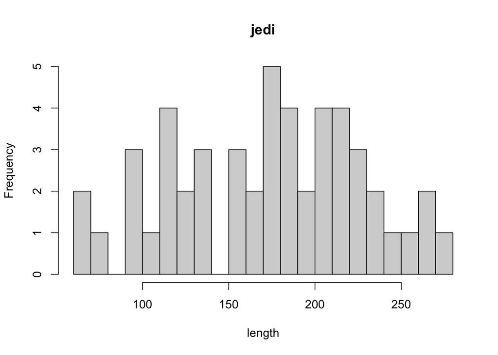

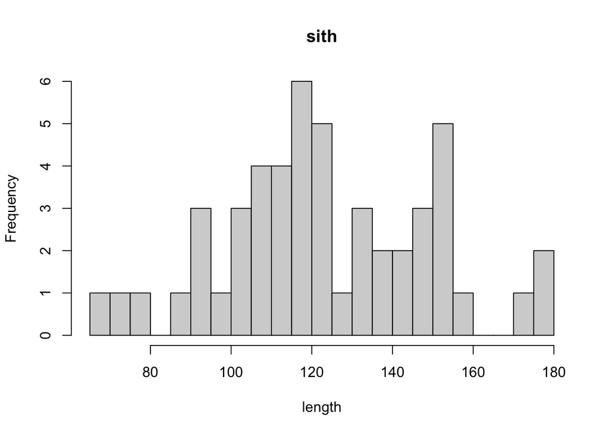

```r
hist(df[df$species == "jedi", "length"], breaks = 20, xlab = "length", main = "jedi")
hist(df[df$species == "sith", "length"], breaks = 20, xlab = "length", main = "sith")
```

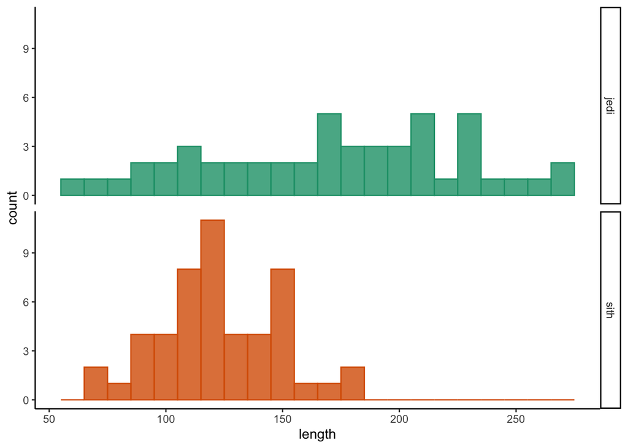

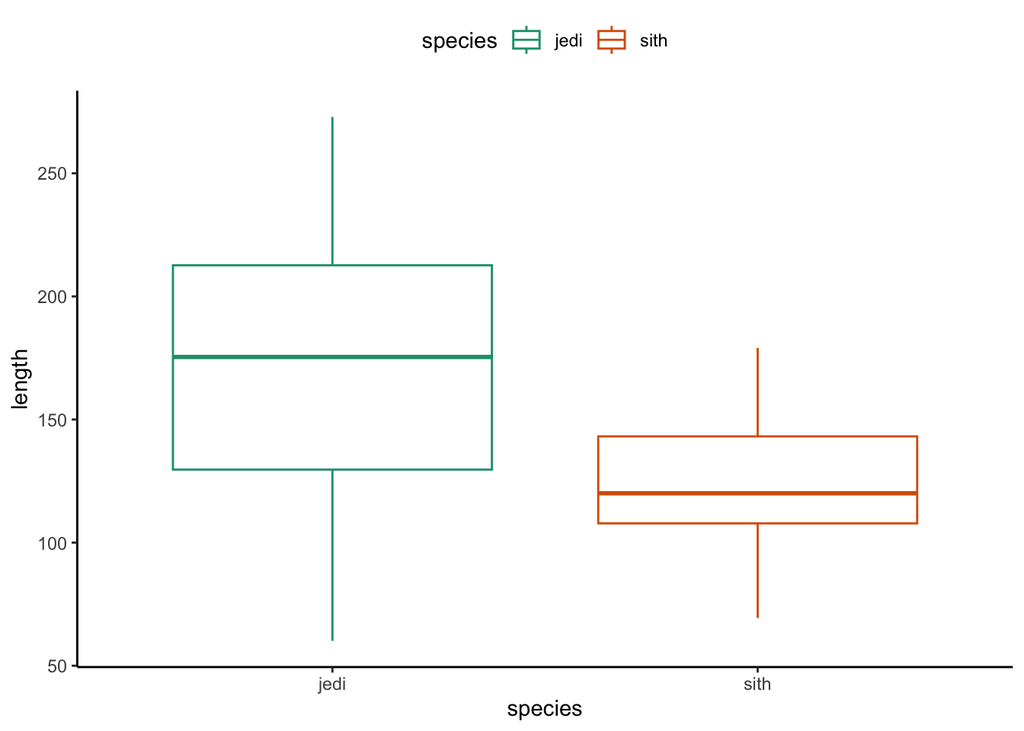

```r
p1 <- ggplot(data = df, aes(x = length, fill = species, color = species)) +
  geom_histogram(binwidth = 10, alpha = 0.8) +
  facet_grid(species ~ .)
p1 <- set_style(p1) + theme(legend.position = "none")
p1
p2 <- ggplot(data = df, aes(x = species, y = length, color = species)) +
  geom_boxplot()
p2 <- set_style(p2)
p2
```

```r
plots <- list(p1, p2)
names(plots) <- c("gg_hist.png", "gg_box.png")
lapply(names(plots), function(x) ggsave(x, plots[[x]]))
```

```
[[1]]
[1] "gg_hist.png"

[[2]]
[1] "gg_box.png"
```

## Load the gene expression data matrix from the ‘microarray_data.tab’ dataset provided in the shared folder, it is a big tabular separated matrix.

1. How big is the matrix in terms of rows and columns?

```r
df <- read.table("microarray_data.tab", sep = "\t", header = T)
size_sum(df)
```

```
[1] "[553 × 1,000]"
```

2. Count the missing values per gene and visualize this result.

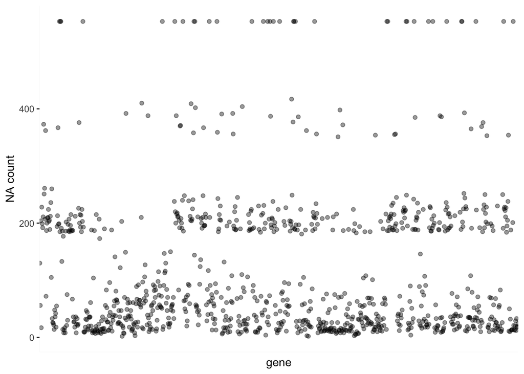

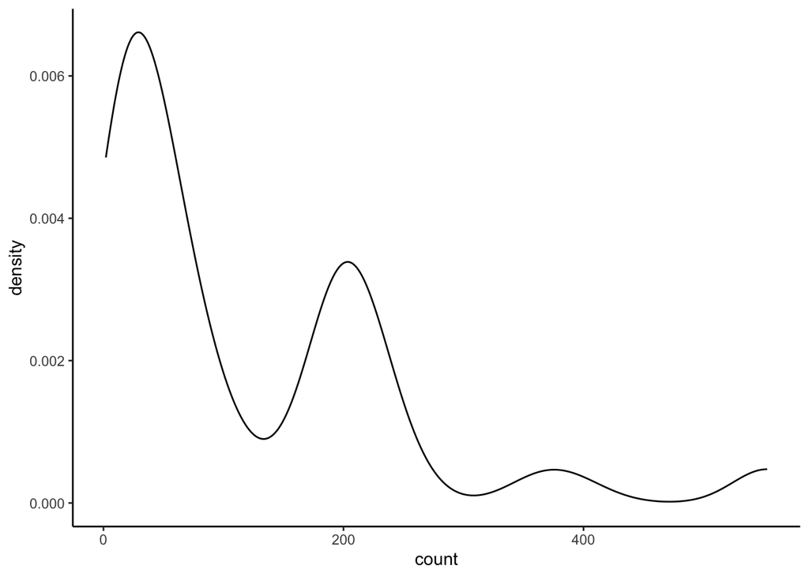

```r
gene_na <- df %>%
  summarise_all(~sum(is.na(.))) %>%
  gather(key = "gene", value = "count")
p1 <- ggplot(gene_na, aes(x = gene, y = count)) +
  geom_point(alpha = 0.4) +
  ylab("NA count") +
  theme(axis.text.x = element_blank(),
        axis.ticks.x = element_blank())
p1
p2 <- ggplot(gene_na, aes(x = count)) +
  geom_density()
set_style(p2)
```

3. Find the genes for which there are more than X% (X=10%, 20%, 50%) missing values.

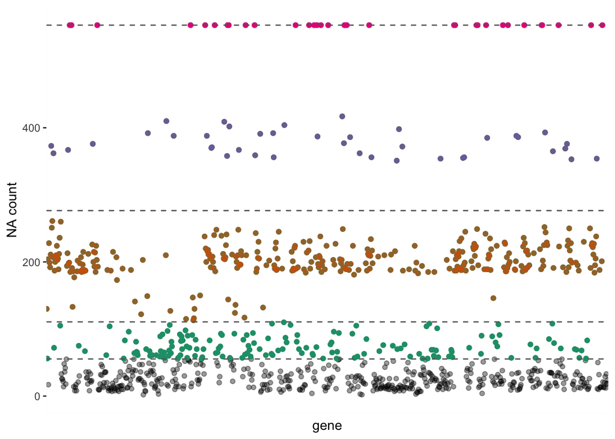

```r
set_10 <- gene_na %>%
  filter(count > nrow(df) * 0.1) %>%
  mutate(category = ">10%")
set_20 <- set_10 %>%
  filter(count > nrow(df) * 0.2) %>%
  mutate(category = ">20%")
set_50 <- set_20 %>%
  filter(count > nrow(df) * 0.5) %>%
  mutate(category = ">50%")
set_na <- gene_na %>%
  filter(count == nrow(df))

p1 +
  geom_point(data = set_10, color = brewer.pal(4, fixed_palette)[1], alpla = 0.4) +
  geom_point(data = set_20, color = brewer.pal(4, fixed_palette)[2], alpha = 0.6) +
  geom_point(data = set_50, color = brewer.pal(4, fixed_palette)[3], alpha = 0.8) +
  geom_point(data = set_na, color = brewer.pal(4, fixed_palette)[4]) +
  geom_hline(yintercept = c(0.1, 0.2, 0.5, 1) * nrow(df), color = "grey40", linetype = "dashed")
```

4. Replace the missing values by the average expression value for the particular gene. (Note: Imputing data has to be used with caution!)

```r
replace_with_mean <- function(v){
  v[is.na(v)] <- mean(v, na.rm = T)
}

df_imputed <- df %>%
  mutate(across(where(is.numeric), ~replace_na(., mean(., na.rm = T))))
df_imputed[1:8, 1:6]
```

```
           g1        g2         g3          g4          g5         g6
1  1.80200000 0.1656927 -0.1820000  1.31200000  3.49700000  0.4390000
2  0.02547518 0.1656927  7.6930000 -0.06731957  0.19300000 -1.3830000
3  1.07900000 0.1656927  1.5560000  1.65200000 -0.01812288  0.4600000
4  3.60700000 0.1656927  1.9140000 -0.06731957  1.40000000  1.1090000
5 -1.70000000 0.1656927  0.9430000 -0.06731957 -0.17000000 -0.1571338
6  0.02547518 0.1656927  0.0430000 -0.06731957  0.72900000 -0.0890000
7  0.02547518 0.1656927 -0.1230605 -0.06731957 -0.01812288 -0.1571338
8  0.02547518 0.1656927 -0.1230605 -0.06731957 -0.01812288 -1.2970000
```

## Visualize the data in the CO2 dataset in a way that gives you a deeper understanding of the data. What do you see?

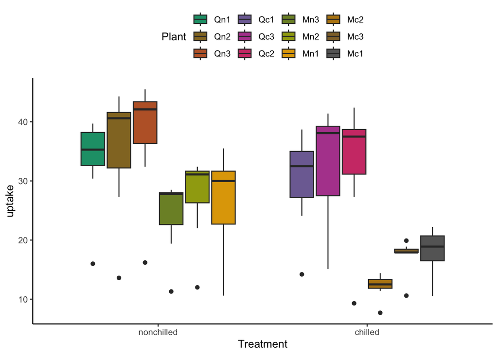

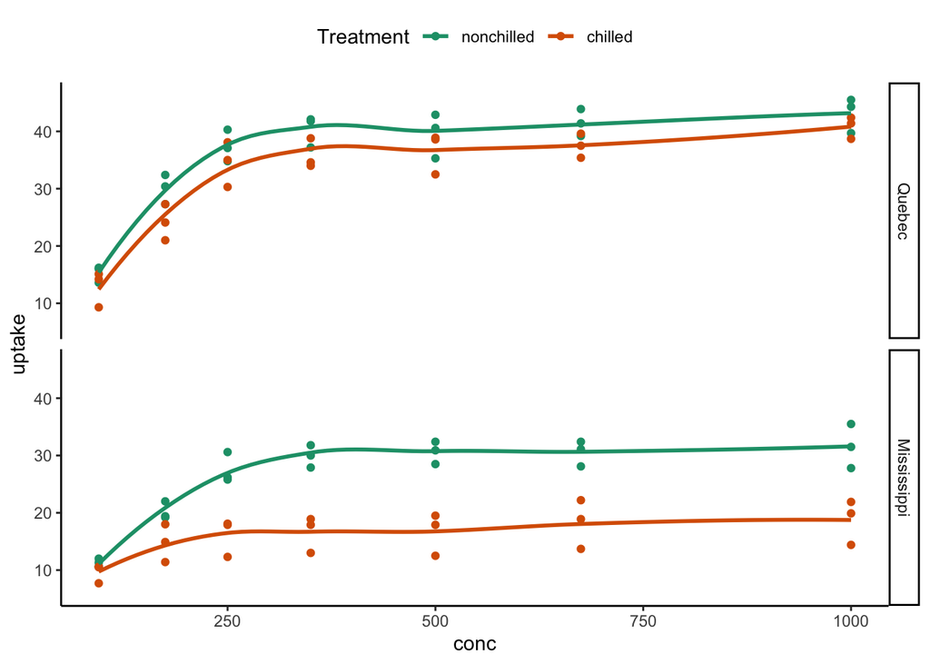

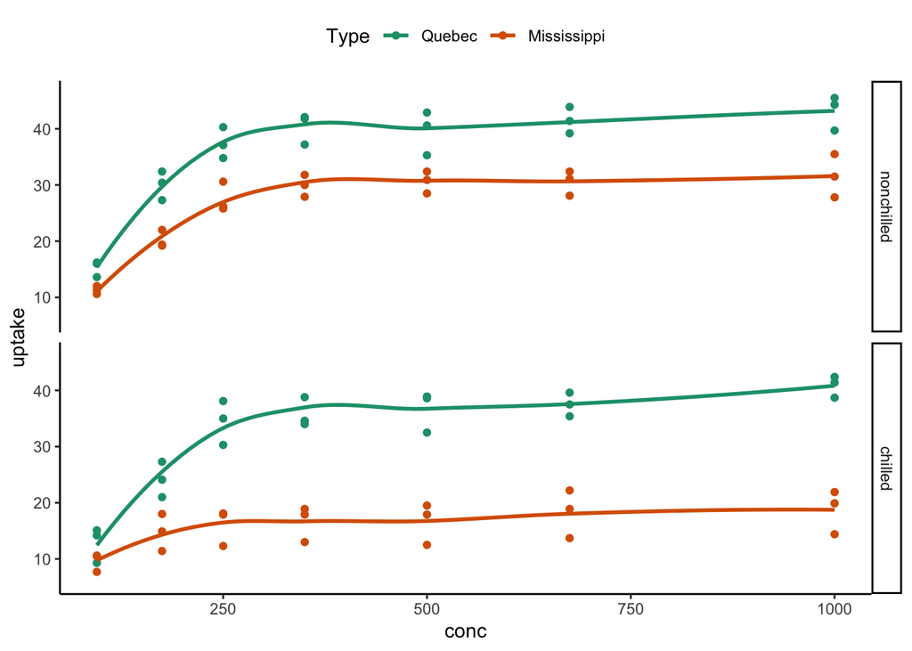

```r
getPallete <- colorRampPalette(brewer.pal(8, fixed_palette))
N_color <- length(unique(CO2$Plant))
p1<- ggplot(CO2, aes(x = Treatment, y = uptake, fill = Plant)) +
  geom_boxplot()
set_style(p1) + scale_fill_manual(values = getPallete(N_color))
p2 <- ggplot(CO2, aes(x = conc, y = uptake, color = Treatment)) +
  geom_point() +
  geom_smooth(method = "loess", fill = NA) +
  facet_grid(Type ~ .)
set_style(p2)
p3 <- ggplot(CO2, aes(x = conc, y = uptake, color = Type)) +
  geom_point() +
  geom_smooth(method = "loess", fill = NA) +
  facet_grid(Treatment ~ .)
set_style(p3)
```

From the above plots I noticed the following:

1. From the boxplot, plants from Quebec have a higher CO<sub>2</sub> uptake rate than Mississippi, whether they were chilled or not before the measurement.
2. Comparing the treatments, chilling decreases the CO<sub>2</sub> uptake rate in general.
3. From the second and the third plot, we can learn the relationship between ambient CO<sub>2</sub> level(conc) and the CO<sub>2</sub> uptake rate of the plants. This relationship of the plants demonstates a similar trend, i.e. CO<sub>2</sub> uptake rate increases as the level of conc increases, with a deceasing rate of change, and eventually reaches a plateau.
4. Whether or not chilled before measurement affects(decreases the uptake rate) the plants from Mississippi more than Quebec.

# Task 8

## Install the Tidybiology package, which includes the data ‘chromosome’ and ‘proteins’.

1. Extract summary statistics (mean, median and maximum) for the following variables from the ‘chromosome’ data: variations, protein coding genes, and miRNAs. Utilize the tidyverse functions to make this as simply as possible.

```r
library(tidybiology)
#colnames(chromosome)
chromosome %>% select(c("variations", "protein_codinggenes", "mi_rna")) %>%
  summarise_all(.funs = list(mean = ~round(mean(.x)), median = median, max = max),
                .names = "{.col}.{.fn}") %>%
  gather(key = "statistics") %>%
  kbl() %>%
  kable_styling()
```

| statistics | value |
| --- | --- |
| variations_mean | 6484572 |
| protein_codinggenes_mean | 850 |
| mi_rna_mean | 73 |
| variations_median | 6172346 |
| protein_codinggenes_median | 836 |
| mi_rna_median | 75 |
| variations_max | 12945965 |
| protein_codinggenes_max | 2058 |
| mi_rna_max | 134 |

2. How does the chromosome size distribute? Plot a graph that helps to visualize this by using ggplot2 package functions.

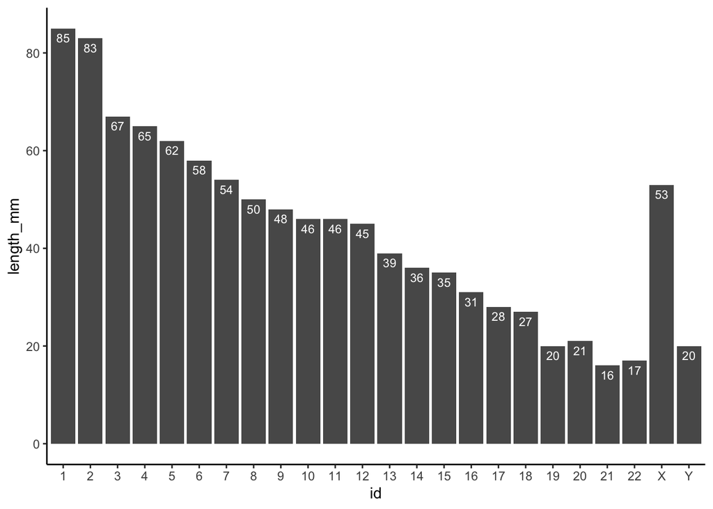

```r
p <- ggplot(chromosome, aes(x = id, y = length_mm)) +
  geom_bar(stat = "identity") +
  geom_text(aes(label = length_mm), vjust = 1.6, color = "white", size = 3)
set_style(p)
```

3. Does the number of protein coding genes or miRNAs correlate with the length of the chromosome? Make two separate plots to visualize these relationships.

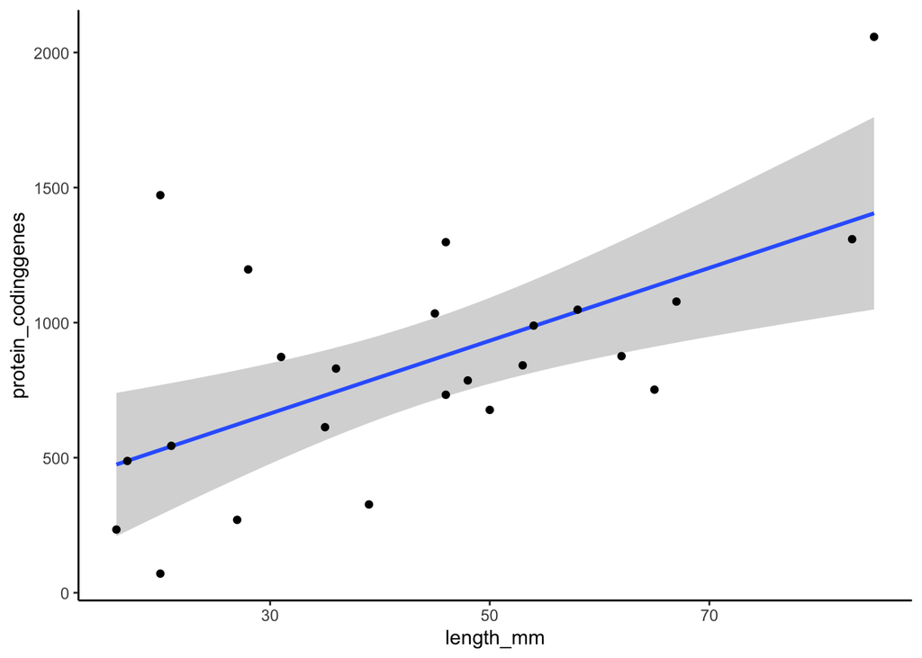

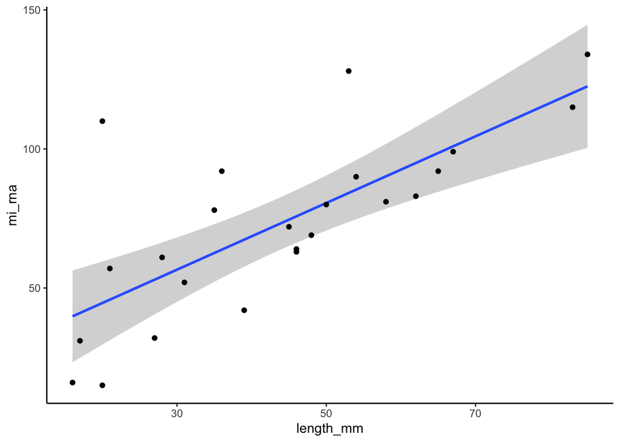

```r
p1 <- ggplot(chromosome, aes(x = length_mm, y = protein_codinggenes)) +
  geom_smooth(method = "lm") +
  geom_point()
set_style(p1)
p2 <- ggplot(chromosome, aes(x = length_mm, y = mi_rna)) +
  geom_smooth(method = "lm") +
  geom_point()
set_style(p2)
```

4. Calculate the same summary statistics for the ‘proteins’ data variables length and mass. Create a meaningful visualization of the relationship between these two variables by utilizing the ggplot2 package functions. Play with the colors, theme- and other visualization parameters to create a plot that pleases you.

| statistics | value |
| --- | --- |
| length_mean | 557.160254527655 |
| mass_mean | 62061.3791483113 |
| length_median | 414 |
| mass_median | 46140.5 |
| length_max | 34350 |
| mass_max | 3816030 |

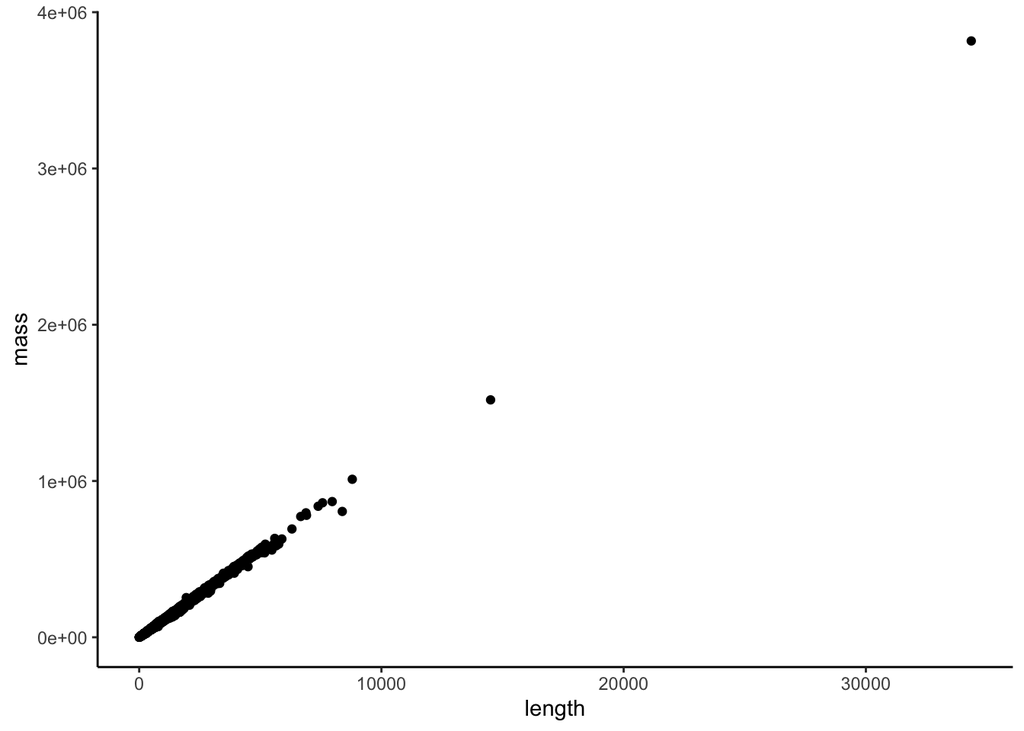

```r
proteins %>% select(c("length", "mass")) %>%
  summarise_all(.funs = list(mean = mean, median = median, max = max),
                .names = "{.col}.{.fn}") %>%
  gather(key = "statistics") %>%
  kbl() %>%
  kable_styling()
p <- ggplot(proteins, aes(x = length, y = mass)) +
  geom_point()
set_style(p)
```